# All Morphology: Wing Statistics

## Wing2Body

### Removing Torn Wings

```r
data_long = remove_torn_wings(data_long)
```

### Winter 2020 vs. other dates

```r
data_long$compare_dates <- -1
data_long$compare_dates[data_long$months_since_start==81] <- 1

compare_dates_model <- glm(wing2body~compare_dates + pophost_binom*sex_binom, data=data_long)

tidy_regression(compare_dates_model, is_color=FALSE)
```

```
## glm wing2body ~ compare_dates + pophost_binom * sex_binom data_long
## AIC:  -8985.245
## (Intercept)              coeff:  0.726747    Pr(>|t|):  0 *
## compare_dates            coeff:  -0.0034365  Pr(>|t|):  3.325641e-11 *
## pophost_binom            coeff:  0.0039501   Pr(>|t|):  1.99932e-18 *
## sex_binom                coeff:  -0.0022857  Pr(>|t|):  1.893713e-07 *
## pophost_binom:sex_binom  coeff:  0.0012163   Pr(>|t|):  0.005315271 *
```

Yes, bugs from this collection date have detectably smaller wing2body ratios on average than other collection dates, even when controlling for sex and host plant.

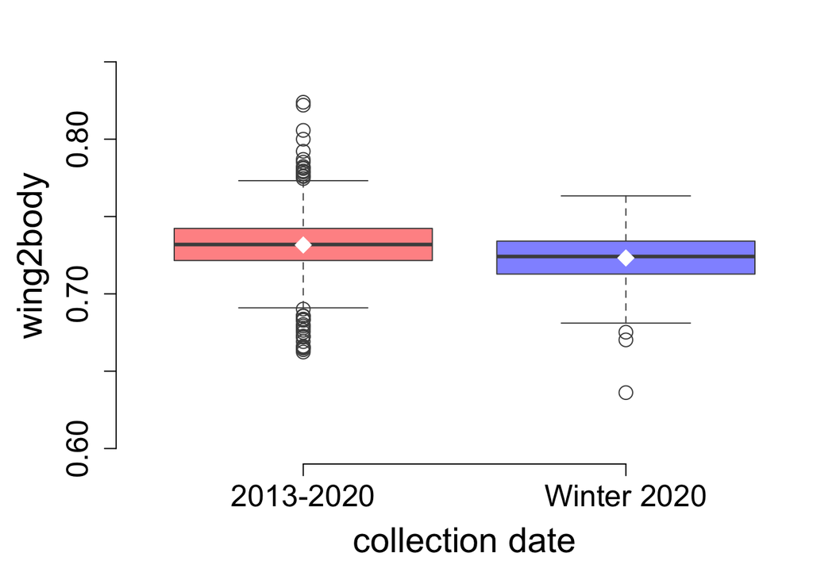

### Binomial Regressions

What effects wing2body ratio? sex? host plant? month of the year? months since start?

```r
data_long$wing2body_c = (data_long$wing2body-mean(data_long$wing2body, na.rm=TRUE))
data_long$month_of_year_c = (data_long$month_of_year-mean(data_long$month_of_year, na.rm=TRUE))
data_long$months_since_start_c = (data_long$months_since_start-mean(data_long$months_since_start, na.rm=TRUE))
```

```r
data<-data.frame(R=data_long$wing2body_c, # centered
                 A=data_long$sex_binom, # sex
                 B=data_long$pophost_binom, # host
                 C=data_long$month_of_year_c,
                 D=data_long$months_since_start_c)

model_script = paste0(source_path,"generic models-gaussian glm 3-FF.R")
model_comparisonsAIC(model_script)
```

```
##        [,1]      [,2]      [,3]      [,4]
## AICs   -8992.343 -8990.65  -8990.422 -8988.734
## models 11        15        14        17
## probs  0.4935323 0.2116732 0.1888527 0.08121813
##
## m11  glm(formula = R ~ A * B + C, family = gaussian, data = data)
## m15  glm(formula = R ~ A * B + B * C, family = gaussian, data = data)
## m14  glm(formula = R ~ A * B + A * C, family = gaussian, data = data)
## m17  glm(formula = R ~ A * B + A * C + B * C, family = gaussian, data = data)
```

```r
anova(m15, m17, test="Chisq") # Adding A*C does not improve fit
```

```
## Analysis of Deviance Table
##
## Model 1: R ~ A * B + B * C
## Model 2: R ~ A * B + A * C + B * C
##   Resid. Df Resid. Dev Df   Deviance Pr(>Chi)
## 1      1705    0.51900
## 2      1704    0.51898  1 2.5537e-05   0.7721
```

```r
anova(m11, m15, test="Chisq") # Adding B*C does not improve fit
```

```
## Analysis of Deviance Table
##
## Model 1: R ~ A * B + C
## Model 2: R ~ A * B + B * C
##   Resid. Df Resid. Dev Df   Deviance Pr(>Chi)
## 1      1706     0.5191
## 2      1705     0.5190  1 9.3105e-05   0.5802
```

```r
anova(m8, m11, test="Chisq") # Adding C does improve fit
```

```
## Analysis of Deviance Table
##
## Model 1: R ~ A * B
## Model 2: R ~ A * B + C
##   Resid. Df Resid. Dev Df Deviance  Pr(>Chi)
## 1      1707    0.53487
## 2      1706    0.51910  1 0.015773 6.031e-13 ***
## ---
## Signif. codes:  0 '***' 0.001 '**' 0.01 '*' 0.05 '.' 0.1 ' ' 1
```

```r
m = glm(wing2body_c ~ sex_binom*pophost_binom + month_of_year_c, data=data_long, family=gaussian)
tidy_regression(m, is_color=FALSE) # m11
```

```
## glm wing2body_c ~ sex_binom * pophost_binom + month_of_year_c gaussian data_long
## AIC:  -8992.343
## (Intercept)              coeff:  -0.0005609  Pr(>|t|):  0.2058978
## sex_binom                coeff:  -0.0021931  Pr(>|t|):  5.164945e-07 *
## pophost_binom            coeff:  0.0039534   Pr(>|t|):  1.243096e-18 *
## month_of_year_c          coeff:  0.0009203   Pr(>|t|):  9.004703e-13 *
## sex_binom:pophost_binom  coeff:  0.001334    Pr(>|t|):  0.002199168 *
```

```r
model_script = paste0(source_path,"generic models-gaussian glm 4-FF.R")
model_comparisonsAIC(model_script)
```

```
##        [,1]      [,2]       [,3]       [,4]       [,5]
## AICs   -8992.343 -8990.65   -8990.422  -8990.417  -8990.107
## models 22        42         40         34         58
## probs  0.1560166 0.06691464 0.05970057 0.05954927 0.051021
##
## m22  glm(formula = R ~ A * B + C, family = gaussian, data = data)
## m42  glm(formula = R ~ A * B + B * C, family = gaussian, data = data)
## m40  glm(formula = R ~ A * B + A * C, family = gaussian, data = data)
## m34  glm(formula = R ~ A * B + C + D, family = gaussian, data = data)
## m58  glm(formula = R ~ A * B + B * D + C, family = gaussian, data = data)
```

```r
anova(m22, m42, test="Chisq") # adding B*C does not improve fit
```

```
## Analysis of Deviance Table
##
## Model 1: R ~ A * B + C
## Model 2: R ~ A * B + B * C
##   Resid. Df Resid. Dev Df   Deviance Pr(>Chi)
## 1      1706     0.5191
## 2      1705     0.5190  1 9.3105e-05   0.5802
```

```r
anova(m16, m22, test="Chisq") # adding C does improve fit # same top model as before
```

```
## Analysis of Deviance Table
##
## Model 1: R ~ A * B
## Model 2: R ~ A * B + C
##   Resid. Df Resid. Dev Df Deviance  Pr(>Chi)
## 1      1707    0.53487
## 2      1706    0.51910  1 0.015773 6.031e-13 ***
## ---
## Signif. codes:  0 '***' 0.001 '**' 0.01 '*' 0.05 '.' 0.1 ' ' 1
```

No months_since_start effect. But can plot the positive effect of month of year on wing2body ratio. It looks cyclical by pophost and more linear by sex:

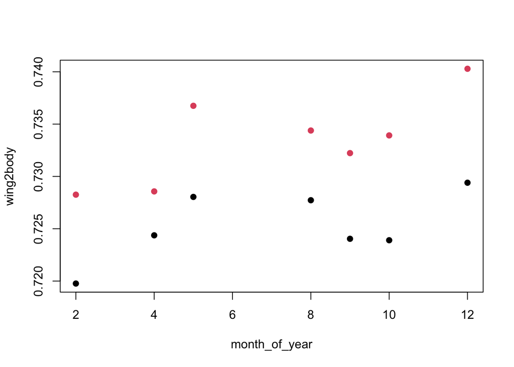

```r
wing2body_summary<-aggregate(wing2body~pophost*month_of_year, data=data_long, FUN=mean)
plot(wing2body~month_of_year, data=wing2body_summary, pch=19, col=c(1,2)[as.factor(pophost)])
```

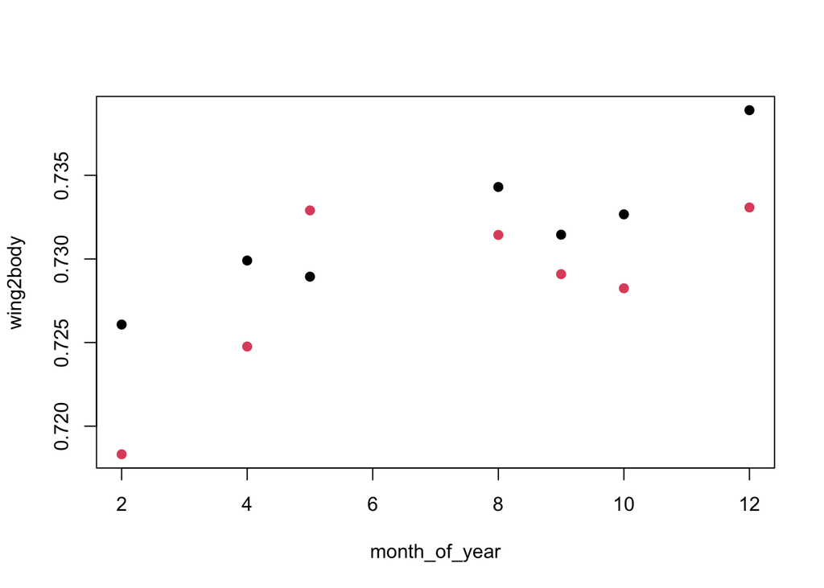

```r
wing2body_summary<-aggregate(wing2body~sex_binom*month_of_year, data=data_long, FUN=mean) # black is M; Red is F
plot(wing2body~month_of_year, data=wing2body_summary, pch=19, col=c(1,2)[as.factor(sex_binom)]) # black is C. ; Red is K.
```

## Winter 2020

```r
rm(list=ls())
source_path = "~/Desktop/git_repositories/SBB-dispersal/avbernat_working_on/Rsrc/"

script_names = c("center_flight_data.R", # Needs to load first
                 "clean_flight_data.R",  # Script that loads and cleans up the data
                 "regression_output.R", # Cleans up regression outputs, prints in color or B&W
                 "clean_morph_data.R")

for (script in script_names) {
  path = paste0(source_path, script)
  source(path)
  }
```

```r
##read in and clean up data
data_winter_full <- read_flight_data("data/all_flight_data-Winter2020.csv")
data_winter_all <- data_winter_full[[1]]
data_winter_tested <- data_winter_full[[2]]

###for these analyses, morphology only
data_winter <- data_winter_tested[,c('beak','thorax', 'wing', 'body', 'w_morph', 'morph_notes')]
```

```r
##load full dataset & pare to long-winged bugs only
data_list <- read_morph_data("data/allmorphology9.21.20-clean.csv")
```

```
## number of missing dates: 0
```

```r
raw_data = data_list[[1]]
data_long = data_list[[2]]
```

```r
data_all_dates<-raw_data[raw_data$w_morph=="L",c('beak','thorax', 'wing', 'body', 'w_morph', 'notes')]
```